# 220323_PLIER_LVs

Jennifer Fisher

3/23/2022

# START

[output not shown]

# STEPS

### Set working directory

```r
library(MatrixGenerics)
library(Biobase)
```

### load in data

```r
recount3_plier <- readRDS("~/data/recount3/recount3_plier_wo.rds")
```

### Analysis

```r
Z_mtx<- recount3_plier$Z
```

```r
rm(recount3_plier_gbm)
gc()
```

```
##              used    (Mb) gc trigger    (Mb)   max used    (Mb)
## Ncells    1108904    59.3    2357862   126.0    1288094    68.8
## Vcells 2148763708 16393.8 2908988114 22193.9 2149082774 16396.3
```

test 3 genes

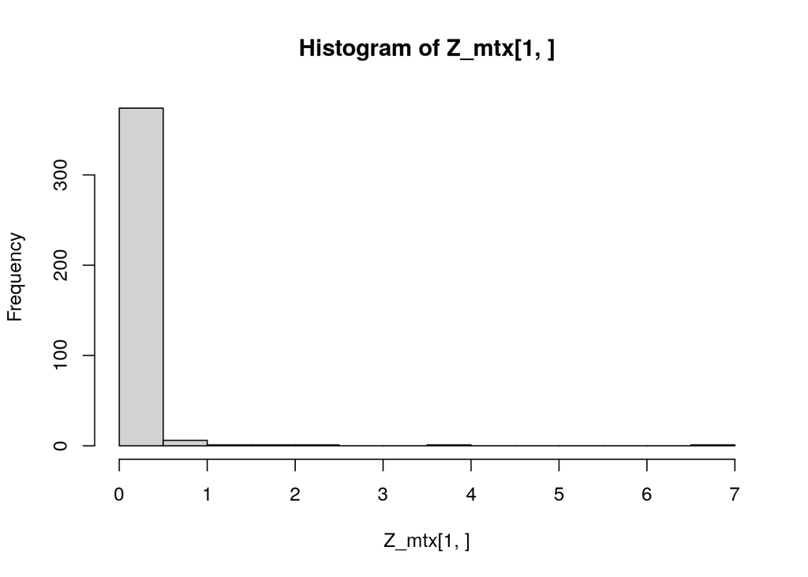

```r
hist(Z_mtx[1,])
```

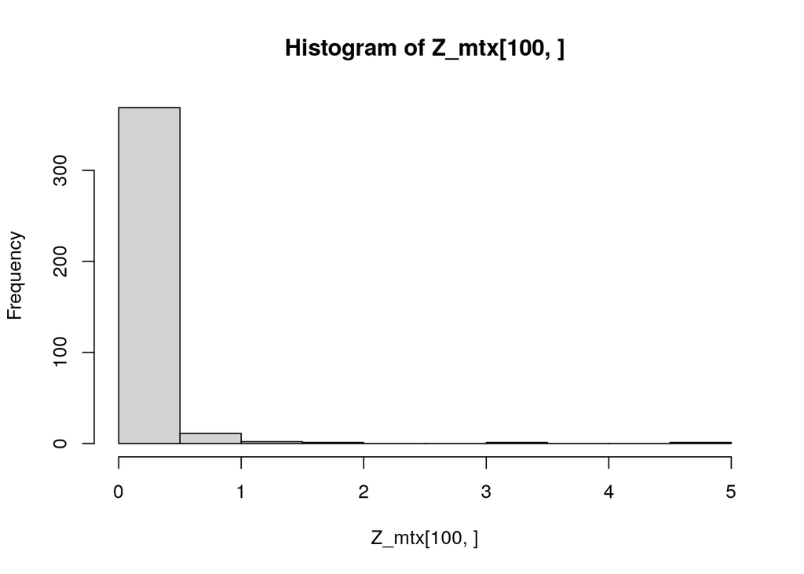

```r
hist(Z_mtx[100,])
```

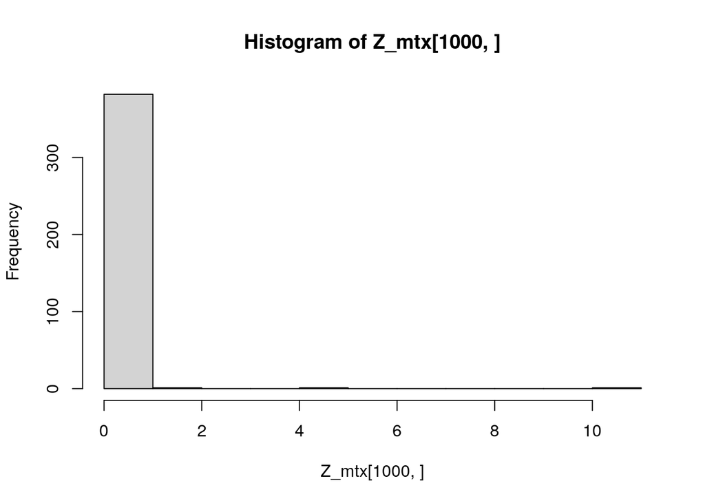

```r
hist(Z_mtx[1000,])
```

usually low for each these genes.

histogram of median

```r
gene_med_weights <- rowMedians(Z_mtx)
```

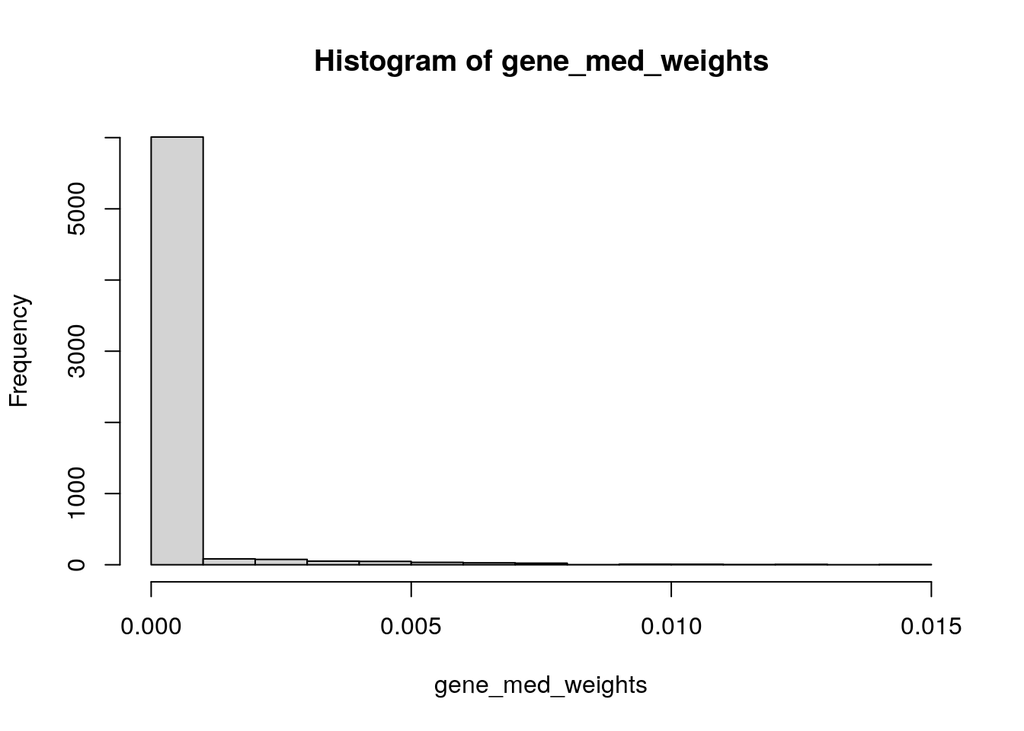

```r
hist(gene_med_weights)
```

```r
gene_avg_weight <- rowMeans(Z_mtx)
```

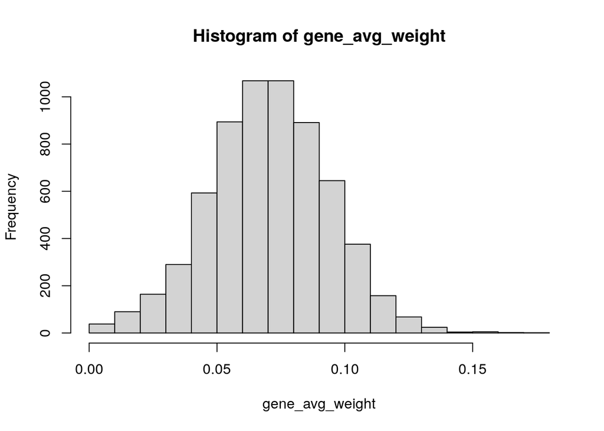

```r
hist(gene_avg_weight)
```

```r
gene_max_weight <- rowMax(Z_mtx)
```

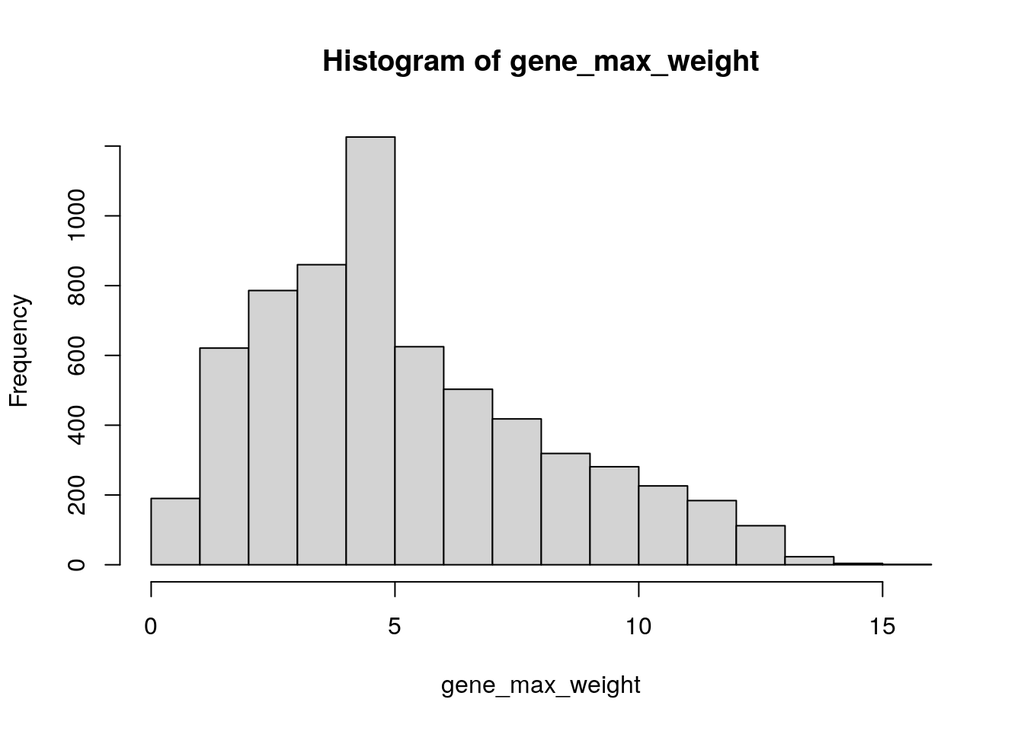

```r
hist(gene_max_weight)
```

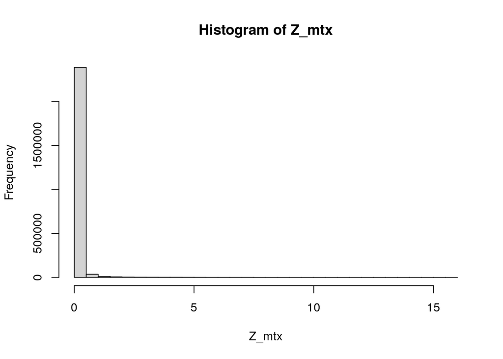

```r
hist(Z_mtx)
```

```r
dim(Z_mtx)
```

```
## [1] 6379  385
```

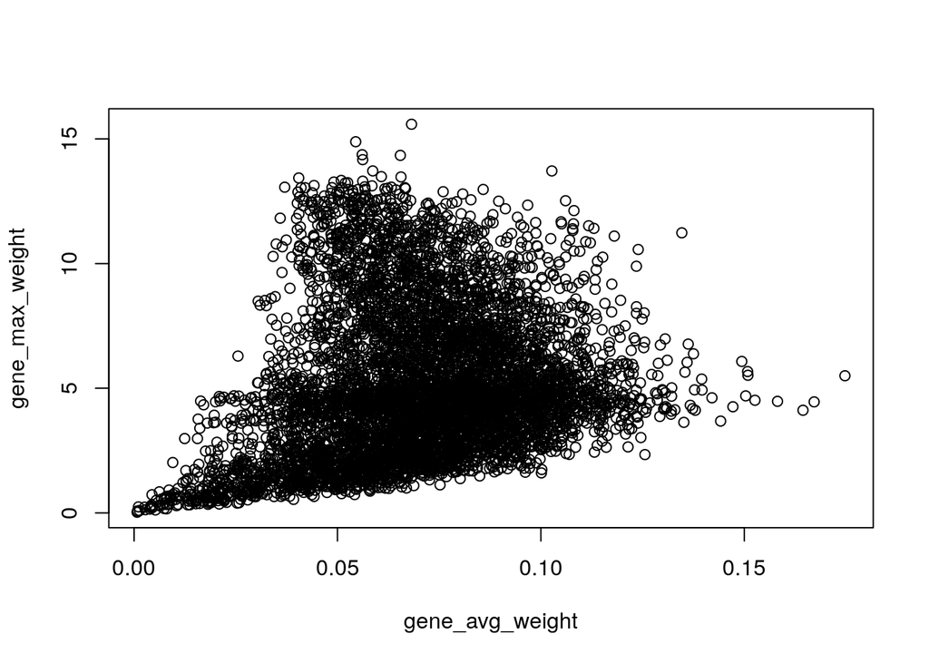

```r
plot(gene_avg_weight, gene_max_weight)
```

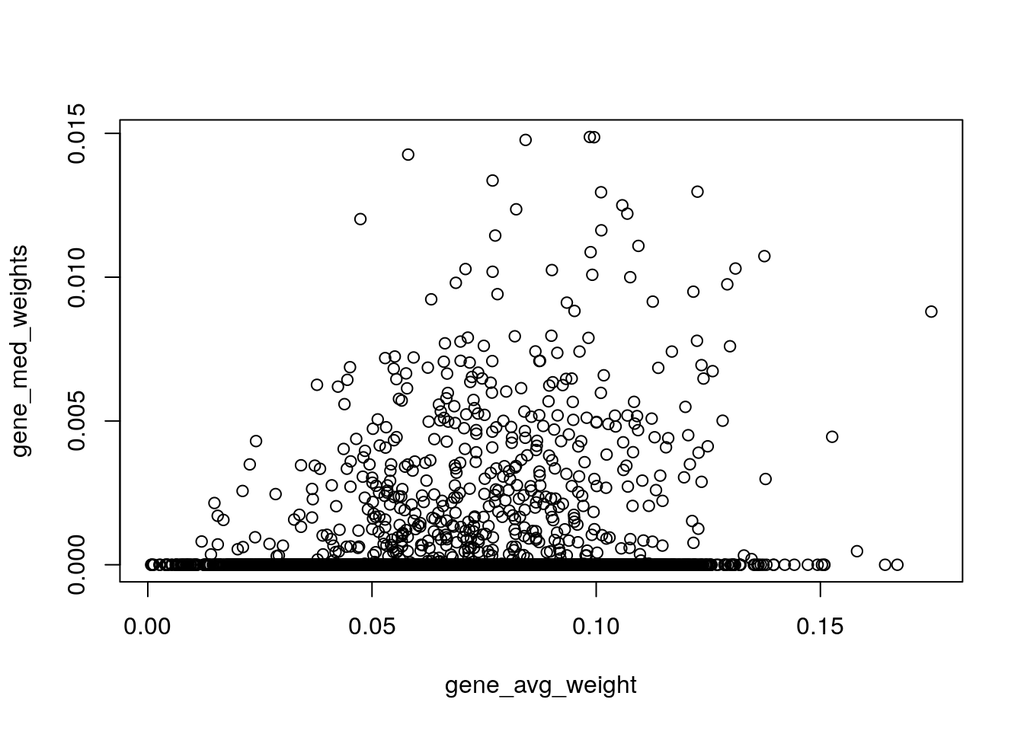

```r
plot(gene_avg_weight, gene_med_weights)
```

there are genes that mostl yhave zero weights with an outlier interesting that are some genes where is seems like they are similar

```r
gene_diff_test <- gene_avg_weight - gene_med_weights
```

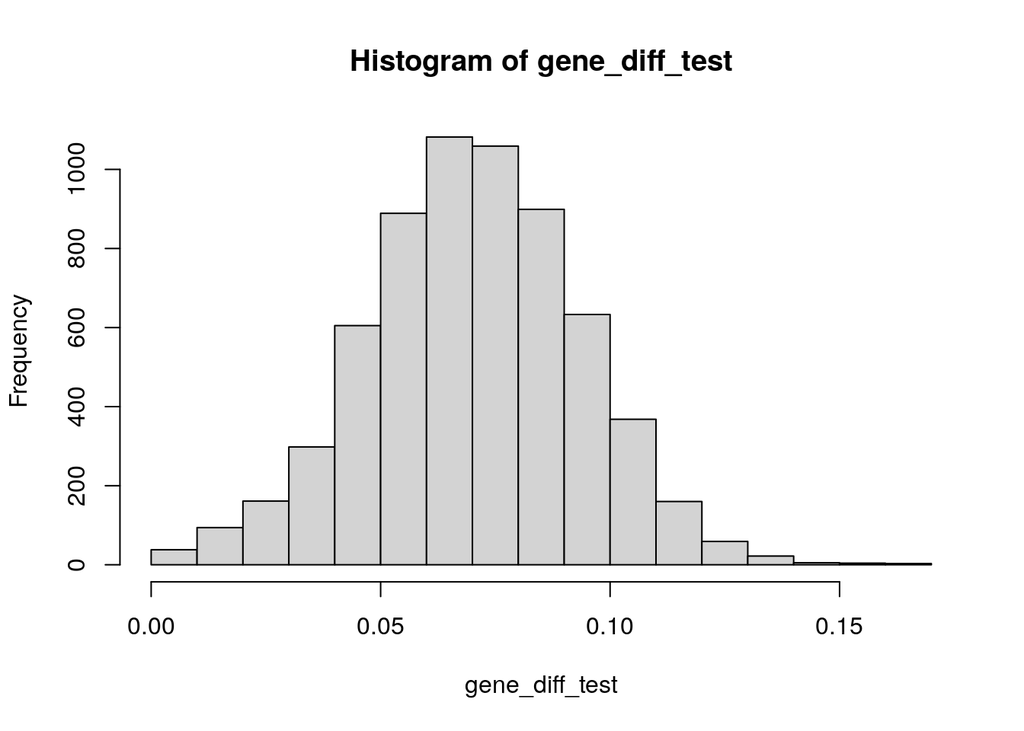

```r
hist(gene_diff_test)
```

```r
table(gene_diff_test <0.02)
```

```
##
## FALSE  TRUE
##  6247   132
```

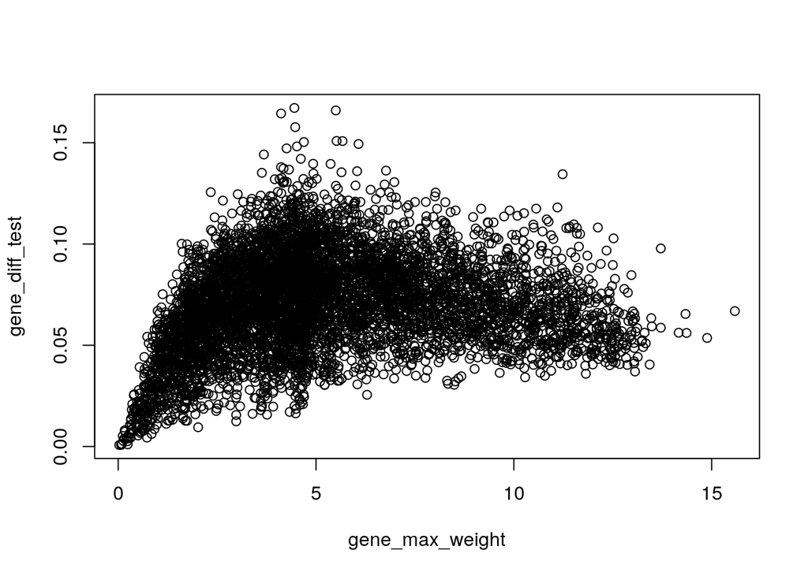

```r
plot(gene_max_weight, gene_diff_test)
```

```r
corr <- gene_diff_test <0.02
```

```r
max_plotting<- cbind(gene_avg_weight, corr)
```

```r
gene_std_weights <- rowSds(Z_mtx)
```

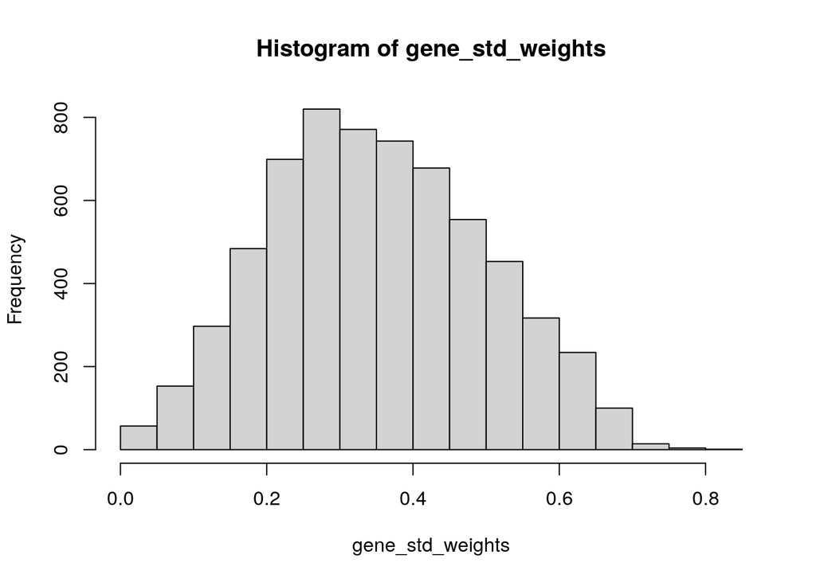

```r
hist(gene_std_weights)
```

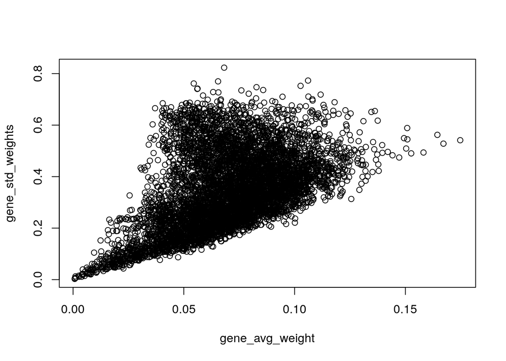

```r
plot(gene_avg_weight, gene_std_weights)
```

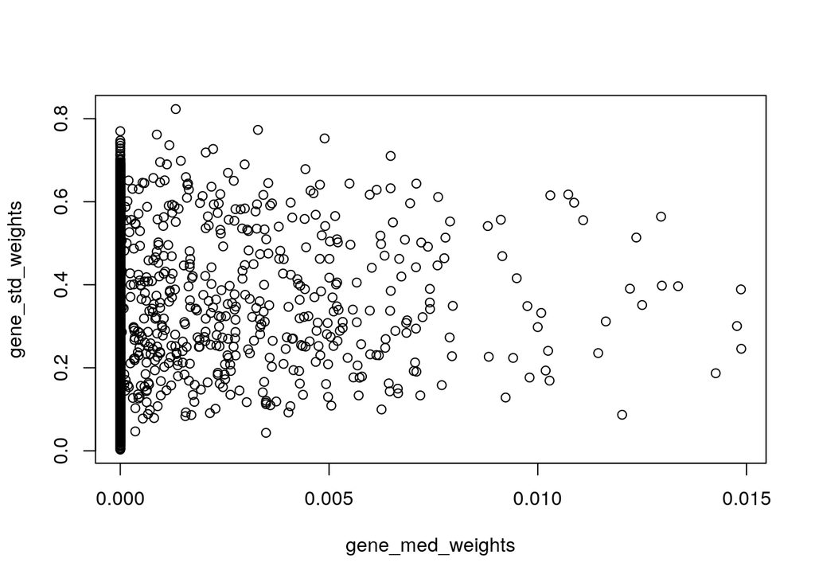

```r
plot(gene_med_weights, gene_std_weights)
```

```r
gene_sp <- cor(t(Z_mtx), method= "spearman")
```

```r
gene_sp_Avg <- rowMeans(gene_sp)
```

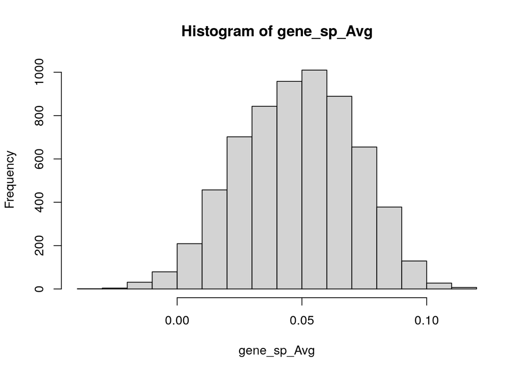

```r
hist(gene_sp_Avg)
```

no correlation between weights and other genes

looking at the string database for these top latent variable genes

```r
ppi <- read.delim("~/data/9606.protein.links.v11.5.txt" , sep= " ", header = TRUE)
```

high confidence - 0.7

```r
ppi$combined_score<- ppi$combined_score /1000
```

```r
ppi$combined_score<- ifelse(ppi$protein1 == ppi$protein2, 1, ppi$combined_score)
```

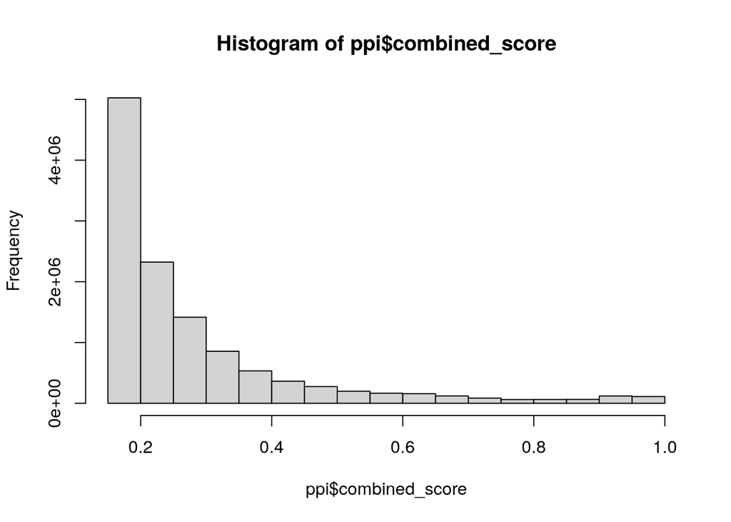

```r
hist(ppi$combined_score)
```

```r
ppi_protein_info<- t(as.data.frame( strsplit(readLines("~/data/9606.protein.info.v11.5.txt"), "\t")))
ppi_protein_info <- as.data.frame(ppi_protein_info)
```

```r
ppi<- ppi[ppi$combined_score >0.7,]
```

```r
protein1_symbols <- c()
protein2_symbols<- c()
for (i in 1:length(ppi$protein1)){
  #print(i)
  protein1_symbols[i]<- ppi_protein_info$V2[ppi$protein1[i] == ppi_protein_info$V1]
  protein2_symbols[i]<-ppi_protein_info$V2[ppi$protein2[i] == ppi_protein_info$V1]
}
scores<- ppi$combined_score
symbol_ppi_table <- cbind(protein1_symbols, protein2_symbols, scores)
```

```r
saveRDS(symbol_ppi_table, "~/string_ppi_symbol.rds")
```

```r
symbol_ppi_table_df <- as.data.frame(symbol_ppi_table)
library(igraph)
g <- graph_from_data_frame(symbol_ppi_table_df , directed=FALSE)
```

calculate centrality metrics

```r
string_ppi_degree<- degree(g)
string_ppi_betweenness<- betweenness(g)
string_ppi_eign_cent <- eigen_centrality(g)
```

```r
string_ppi_eign_cent_vector <- string_ppi_eign_cent$vector
```

```r
string_ppi_details <-data.frame(degree= string_ppi_degree, betweenness= string_ppi_betweenness, eign_cent= string_ppi_eign_cent_vector)
```

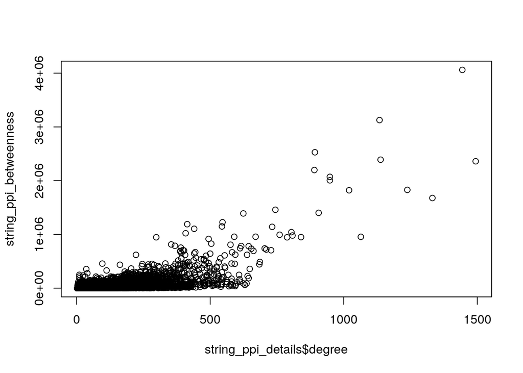

```r
plot(string_ppi_details$degree, string_ppi_betweenness)
```

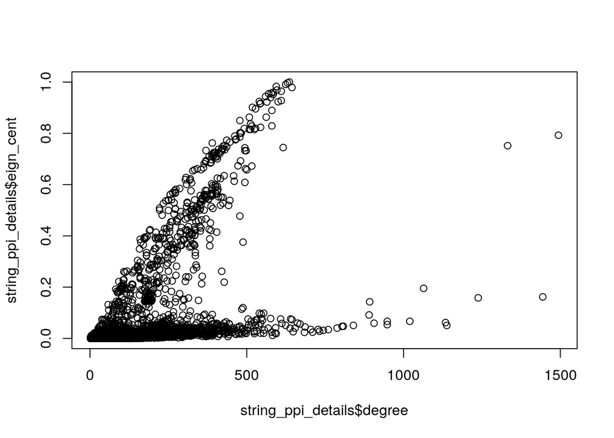

```r
plot(string_ppi_details$degree, string_ppi_details$eign_cent)
```

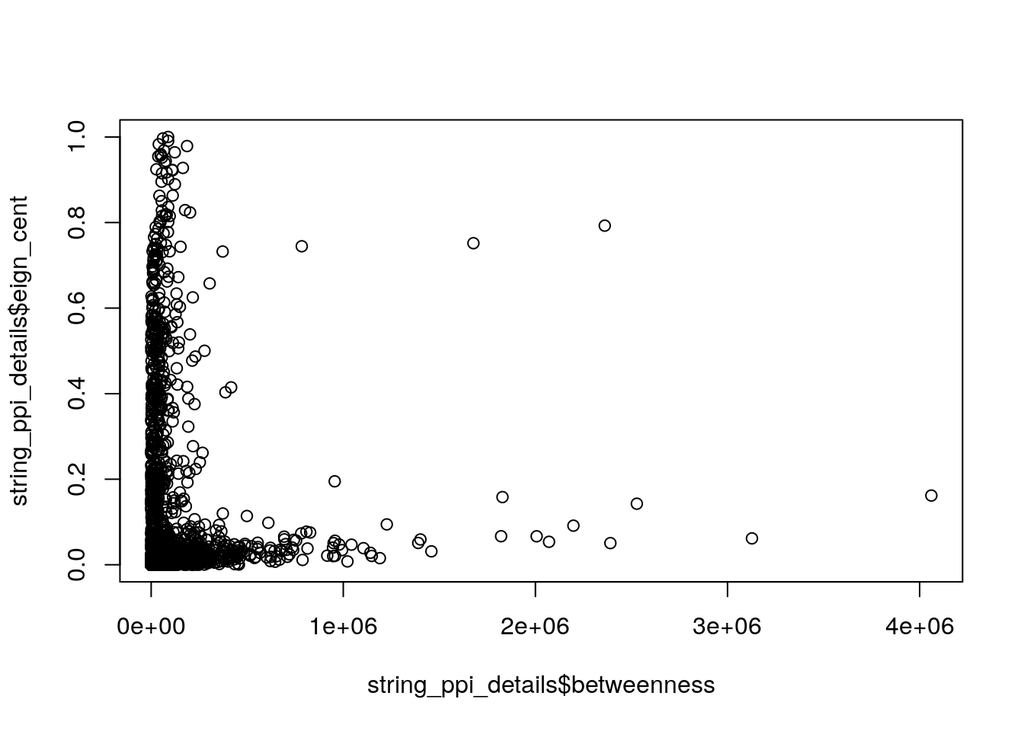

```r
plot(string_ppi_details$betweenness, string_ppi_details$eign_cent)
```

```r
saveRDS(string_ppi_details, "~/string_ppi_metrics.rds")
```

```r
#compare all the lvs GENE list

#5, 10, 15, 20, 25, 30, 35, 40, 45, 50, 55, 60, 65, 70, 75, 80, 85, 90, 95, 100
top_genes_num <- seq(from=2 , to= 100, by=2)
fraction <- c()
for (i in 1:length(top_genes_num)){
  gene_list<- c()
  num<- top_genes_num[i]
  for (j in 1:ncol(Z_mtx)) {
    topgene<- rownames(Z_mtx)[order(-Z_mtx[,j])][1:num]
    gene_list <- c(gene_list, topgene)
  }
  top <- length(unique(gene_list))
  bottom<- num *ncol(Z_mtx)
  fraction[i]<- top/bottom
}
```

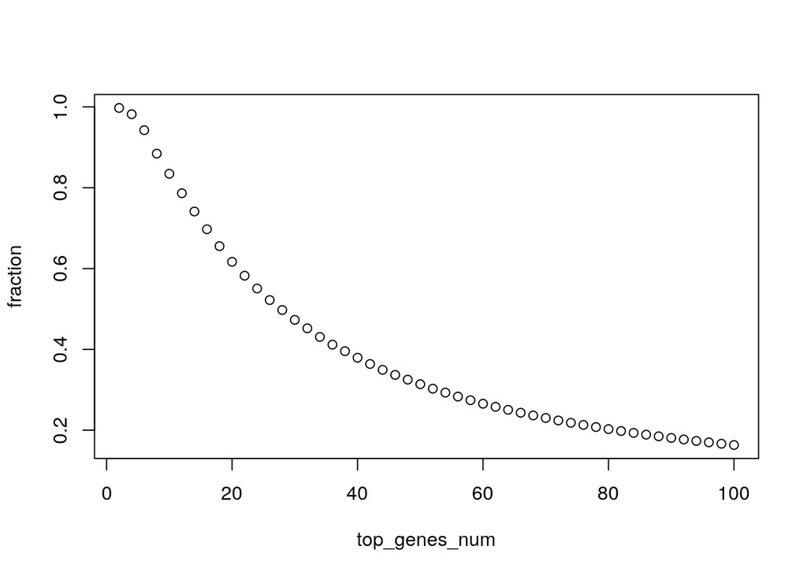

```r
plot(top_genes_num, fraction)
```

```r
lv_topgene_data<- data.frame(Number= top_genes_num, Unique_fraction =fraction)
```

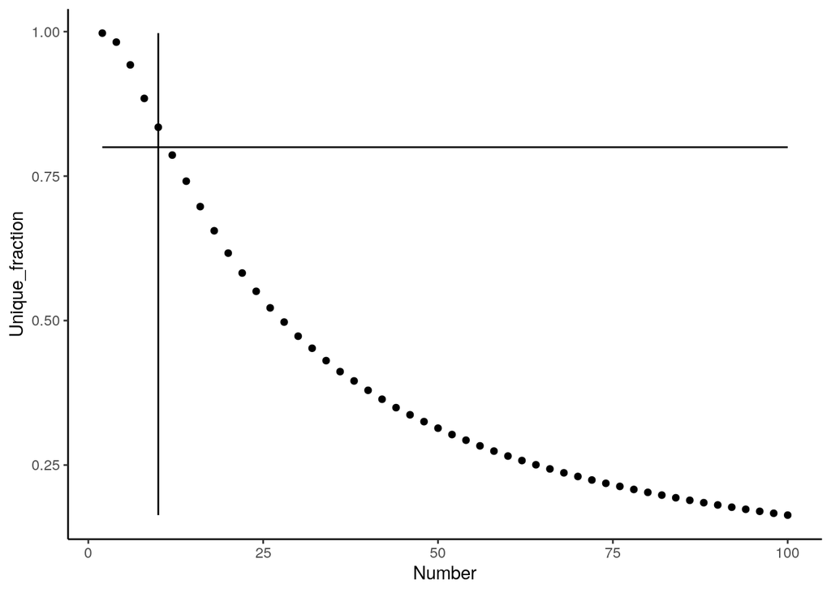

```r
library(ggplot2)
ggplot(lv_topgene_data, aes(x= Number, y= Unique_fraction))+geom_point()+theme_classic()+ geom_line(aes(y=0.80))+ geom_line(aes(x=10))
```

```r
  gene_list<- c()
  num<- top_genes_num[i]
  for (j in 1:ncol(Z_mtx)) {
    topgene<- rownames(Z_mtx)[order(-Z_mtx[,j])][1:10]
    gene_list <- c(gene_list, topgene)
  }
```

```r
length(gene_list)
```

```
## [1] 3850
```

This line plot with the overlap between top genes (Number on the x-axis) and the unique function which describe the number of all the top genes from each LVs (removing repeats) over the total number of genes (without removing shared top genes). The vertical line is at 10 top genes and the horizontal line is at 0.80 were the cut offs for the top genes for this network analysis.

```r
library(dplyr)
string_ppi_details$top_10_weights <- rownames(string_ppi_details) %in% gene_list
```

```r
library(ggplot2)
```

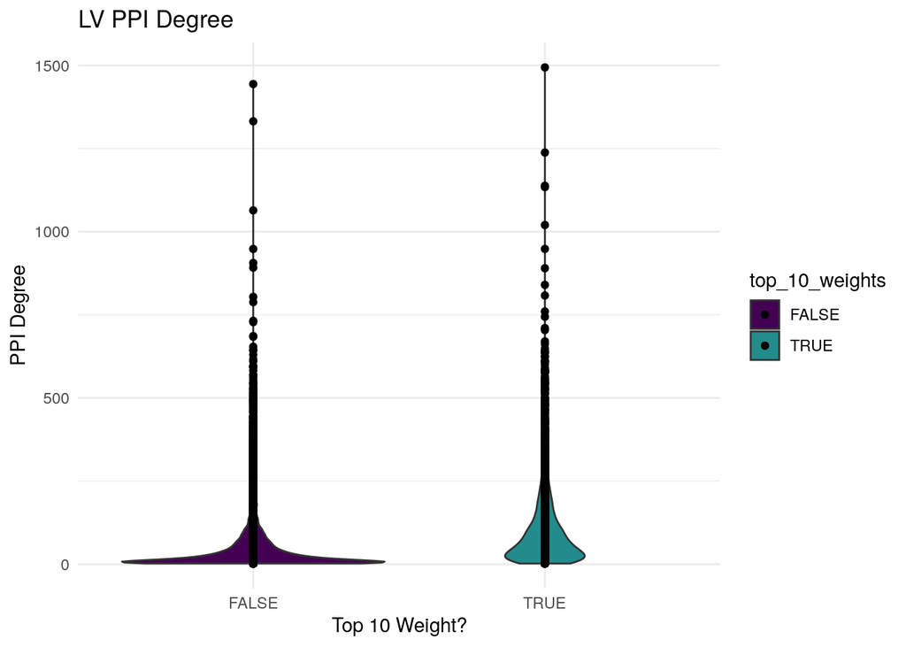

```r
ggplot(string_ppi_details, aes(x=top_10_weights, y=degree, fill=top_10_weights )) +
  geom_violin()+ geom_point() +labs(title="LV PPI Degree",x="Top 10 Weight?", y = "PPI Degree", color= "Top 10 Weight?") + scale_colour_manual(values =  c("#440154FF","#228C8DFF"), aesthetics = c("colour", "fill"))+ theme_minimal()
```

```r
string_ppi_details$degree_log<- log(string_ppi_details$degree +1)
```

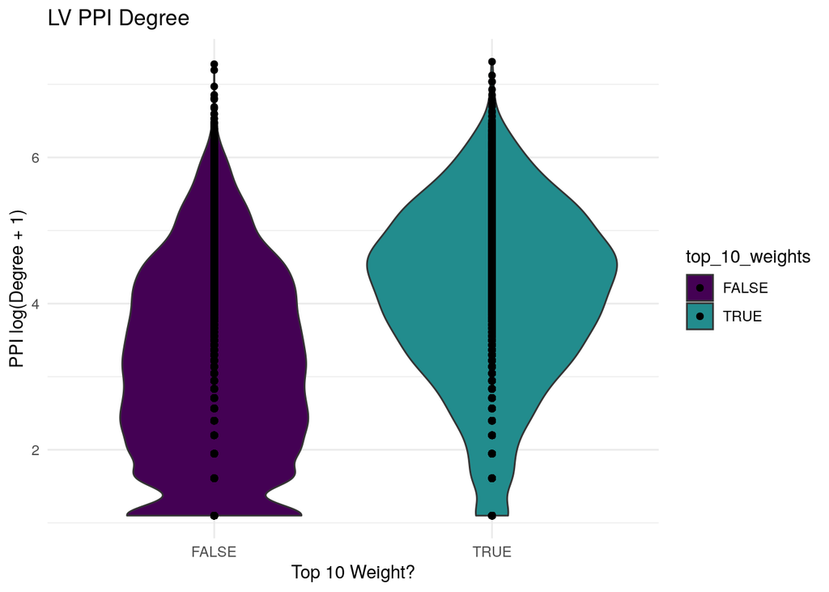

```r
ggplot(string_ppi_details, aes(x=top_10_weights, y=degree_log, fill=top_10_weights )) +
  geom_violin()+ geom_point() +labs(title="LV PPI Degree",x="Top 10 Weight?", y = "PPI log(Degree + 1)", color= "Top 10 Weight?") + scale_colour_manual(values =  c("#440154FF","#228C8DFF"), aesthetics = c("colour", "fill"))+ theme_minimal()
```

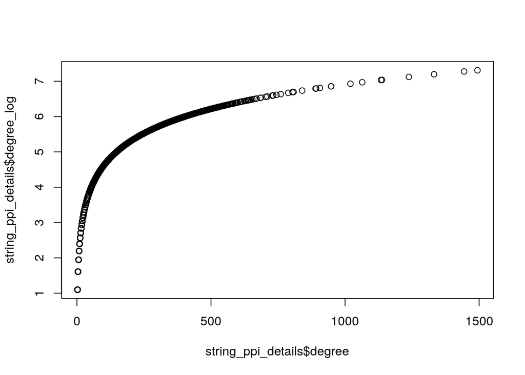

```r
plot(string_ppi_details$degree, string_ppi_details$degree_log)
```

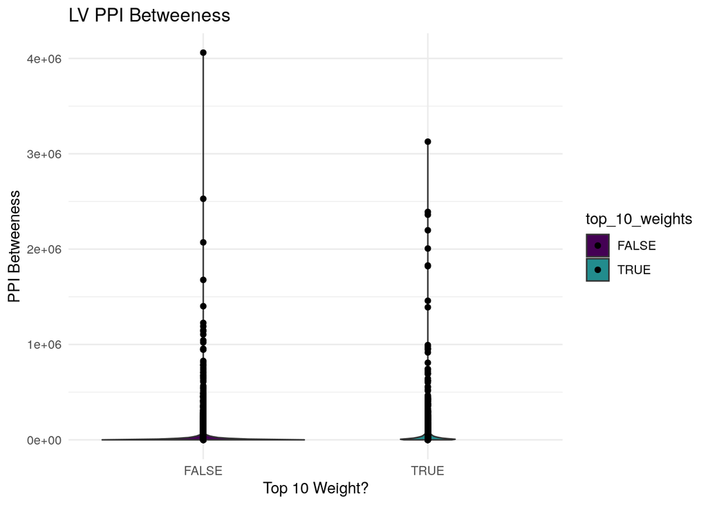

```r
ggplot(string_ppi_details, aes(x=top_10_weights, y=betweenness, fill=top_10_weights)) +
  geom_violin()+ geom_point() +labs(title="LV PPI Betweeness",x="Top 10 Weight?", y = "PPI Betweeness", color= "Top 10 Weight?") + scale_colour_manual(values =  c("#440154FF","#228C8DFF"), aesthetics = c("colour", "fill"))+ theme_minimal()
```

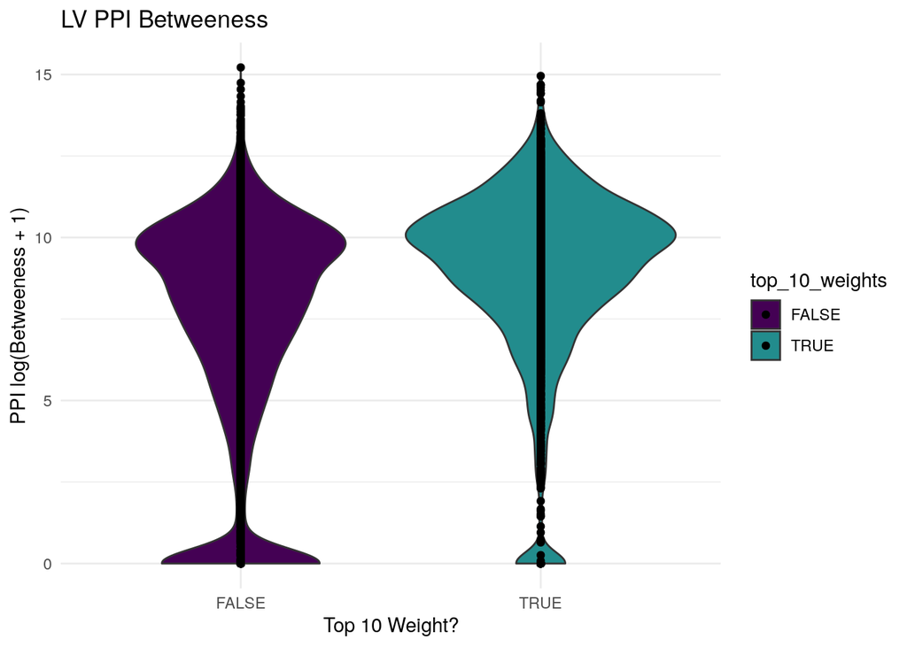

```r
string_ppi_details$log_betweness <- log(string_ppi_details$betweenness + 1)
ggplot(string_ppi_details, aes(x=top_10_weights, y=log_betweness , fill=top_10_weights)) +
  geom_violin()+ geom_point() +labs(title="LV PPI Betweeness",x="Top 10 Weight?", y = "PPI log(Betweeness + 1)", color= "Top 10 Weight?") + scale_colour_manual(values =  c("#440154FF","#228C8DFF"), aesthetics = c("colour", "fill"))+ theme_minimal()
```

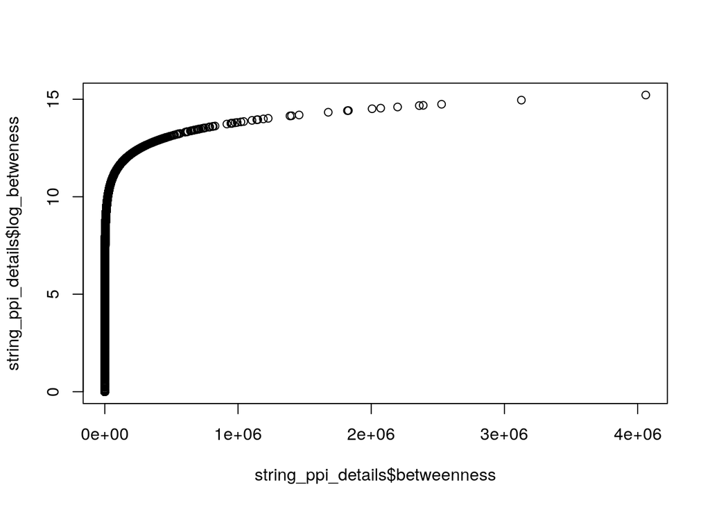

```r
plot(string_ppi_details$betweenness, string_ppi_details$log_betweness)
```

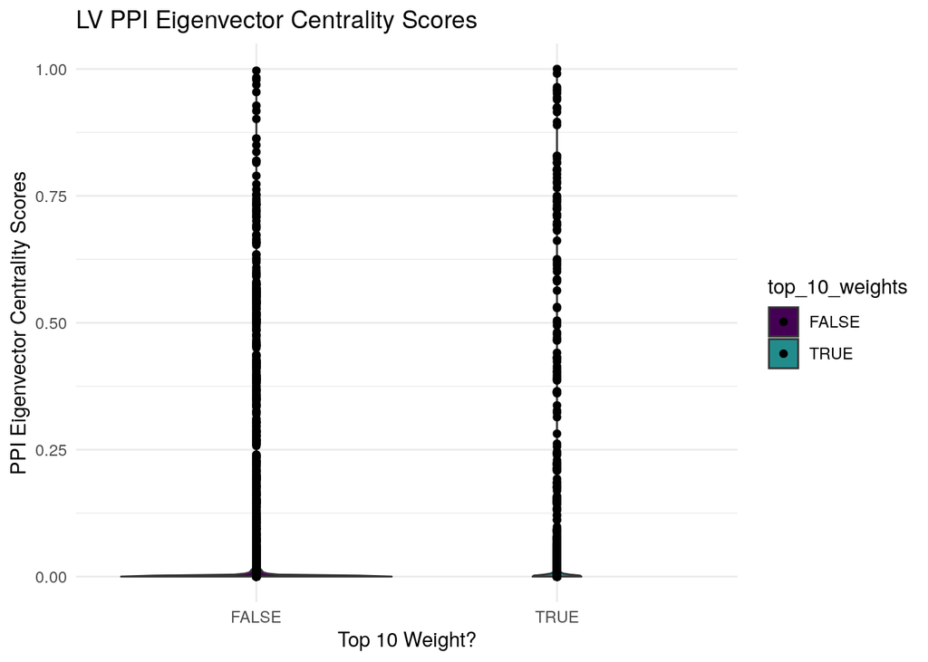

```r
ggplot(string_ppi_details, aes(x=top_10_weights, y=eign_cent, fill=top_10_weights)) +
  geom_violin()+ geom_point() +labs(title="LV PPI Eigenvector Centrality Scores",x="Top 10 Weight?", y = "PPI Eigenvector Centrality Scores", color= "Top 10 Weight?") + scale_colour_manual(values =  c("#440154FF","#228C8DFF"), aesthetics = c("colour", "fill"))+ theme_minimal()
```

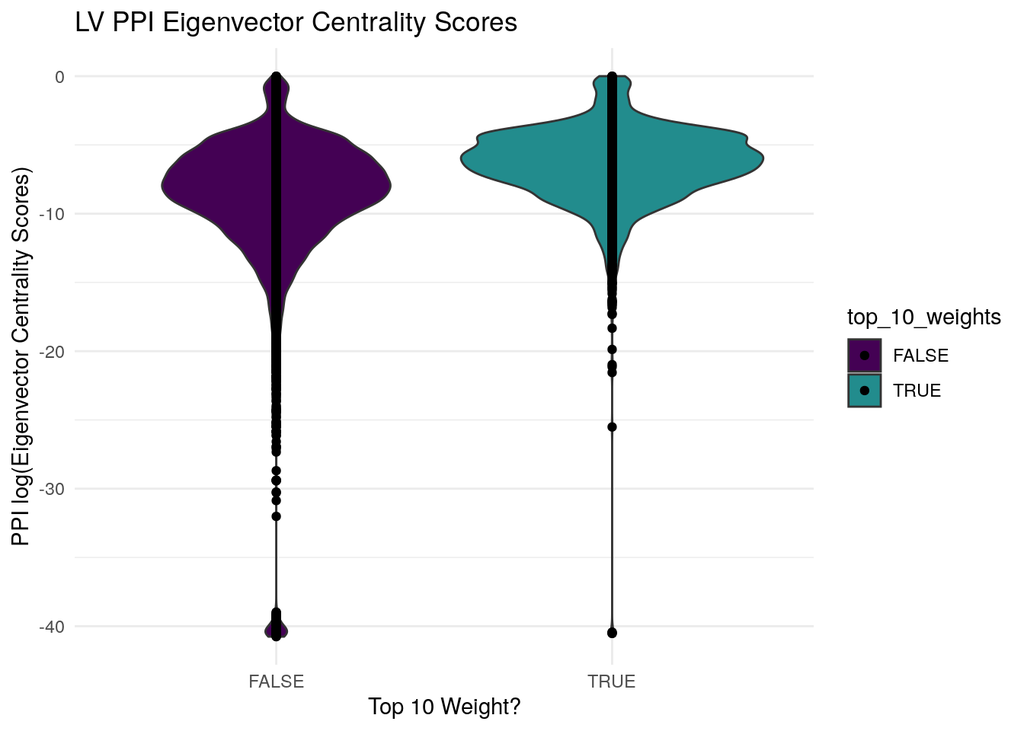

```r
string_ppi_details$eign_cent_log <- log(string_ppi_details$eign_cent)
ggplot(string_ppi_details, aes(x=top_10_weights, y=eign_cent_log, fill=top_10_weights)) +
  geom_violin()+ geom_point() +labs(title="LV PPI Eigenvector Centrality Scores",x="Top 10 Weight?", y = "PPI log(Eigenvector Centrality Scores)", color= "Top 10 Weight?") + scale_colour_manual(values =  c("#440154FF","#228C8DFF"), aesthetics = c("colour", "fill"))+ theme_minimal()
```

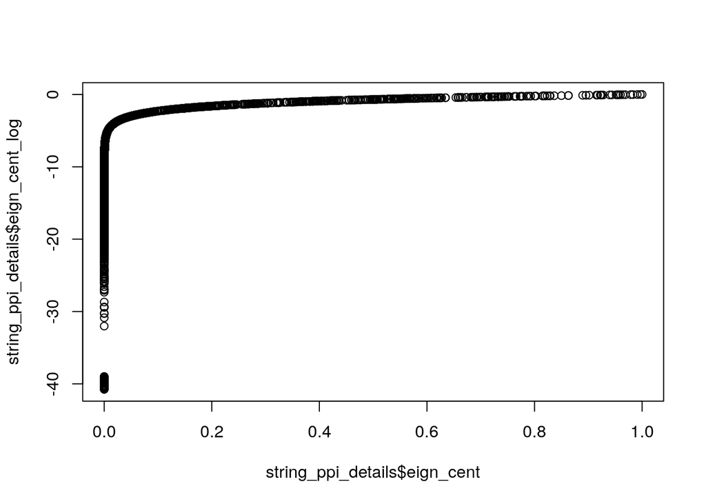

```r
plot(string_ppi_details$eign_cent, string_ppi_details$eign_cent_log)
```

Conduct wilcox test to determine if there is a difference in network centrailtity betweeen genes that are higly weighted in teh latent variables vs not highly weighted.

```r
#
string_ppi_details_true <- string_ppi_details[string_ppi_details$top_10_weights == TRUE,]
string_ppi_details_false <- string_ppi_details[string_ppi_details$top_10_weights == FALSE,]
```

```r
test1 <- wilcox.test(string_ppi_details_true$degree, string_ppi_details_false$degree)
```

```r
p.adjust(test1$p.value, method= "bonferroni", n= 3)
```

```
## [1] 0
```

```r
test2<- wilcox.test(string_ppi_details_true$betweenness, string_ppi_details_false$betweenness)
```

```r
p.adjust(test2$p.value, method= "bonferroni", n= 3)
```

```
## [1] 1.883475e-176
```

```r
test3<- wilcox.test(string_ppi_details_true$eign_cent, string_ppi_details_false$eign_cent)
```

```r
p.adjust(test3$p.value, method= "bonferroni", n= 3)
```

```
## [1] 1.254913e-231
```

```r
dim(string_ppi_details)
```

```
## [1] 16793     7
```

# END

```
Location of final scripts:
scripts

Location of data produced:
output

Dates when operations were done:
220323-220426
```